# 3.Time-Heatmap-GO

#### 1. Load TrendCatcher R package.

```r
library(TrendCatcher)
```

#### 2. Now read the demo master.list.

```r
demo.master.list.path<-system.file("extdata", "BrainMasterList.rda", package = "TrendCatcher")
load(demo.master.list.path)
```

To run TimeHeatmap function, the master.table must include “Symbol” column with gene symbols.

```r
gene.symbol.df<-get_GeneEnsembl2Symbol(ensemble.arr = master.list$master.table$Gene)
master.table.new<-cbind(master.list$master.table, gene.symbol.df[match(master.list$master.table$Gene, gene.symbol.df$Gene), c("Symbol", "description")])
master.list$master.table<-master.table.new
head(master.list$master.table)
```

```
##                    Gene  pattern start.idx end.idx     dynTime  dynSign start.t
## 1330 ENSMUSG00000025283 up_down_      1_4_    4_6_ 6_24_48_72_ +_+_+_+_   0_48_
## 1857 ENSMUSG00000028967 up_down_      1_2_    2_6_    6_24_48_   +_+_+_    0_6_
## 2886 ENSMUSG00000039236 up_down_      1_2_    2_6_       6_24_     +_+_    0_6_
## 4179 ENSMUSG00000078920 up_down_      1_2_    2_6_    6_24_48_   +_+_+_    0_6_
## 4437 ENSMUSG00000105987 up_down_      1_4_    4_6_ 6_24_48_72_ +_+_+_+_   0_48_
## 973  ENSMUSG00000022221 up_down_      1_3_    3_6_ 6_24_48_72_ +_+_+_+_   0_24_
##        end.t         pattern_str dyn.p.val dyn.p.val.adj   Symbol
## 1330 48_168_ 0h_up_48h_down_168h  1.11e-16  4.615657e-13     Sat1
## 1857  6_168_  0h_up_6h_down_168h  1.11e-16  4.615657e-13   Errfi1
## 2886  6_168_  0h_up_6h_down_168h  1.11e-16  4.615657e-13    Isg20
## 4179  6_168_  0h_up_6h_down_168h  1.11e-16  4.615657e-13    Ifi47
## 4437 48_168_ 0h_up_48h_down_168h  2.22e-16  7.385052e-13 AI506816
## 973  24_168_ 0h_up_24h_down_168h  3.33e-16  9.231315e-13    Ripk3
##                                                                             description
## 1330      spermidine/spermine N1-acetyl transferase 1 [Source:MGI Symbol;Acc:MGI:98233]
## 1857             ERBB receptor feedback inhibitor 1 [Source:MGI Symbol;Acc:MGI:1921405]
## 2886                  interferon-stimulated protein [Source:MGI Symbol;Acc:MGI:1928895]
## 4179            interferon gamma inducible protein 47 [Source:MGI Symbol;Acc:MGI:99448]
## 4437                    expressed sequence AI506816 [Source:MGI Symbol;Acc:MGI:2140929]
## 973  receptor-interacting serine-threonine kinase 3 [Source:MGI Symbol;Acc:MGI:2154952]
```

```r
### ONLY use this command if CSV file is using GENE SYMBOL as row name!!!!!!
#master.list$master.table$Symbol<-master.list$master.table$Gene
```

#### 3. Use GO enrichment analysis to construct Time-Heatmap

To draw Time-Heatmap using GO database, please use draw_TimeHeatmap_GO function. This function will return a list composed of a TimeHeatmap plot and a merge.df dataframe. Due to the limited size of Time-Heatmap for visualization, users can play with merge.df which includes all the GO enrichment analysis for each time window.

The full version of GO enrichment output.

```r
# To save time, directely load from extdata
demo.time.heatmap.path<-system.file("extdata", "Brain_TimeHeatmap.rda", package = "TrendCatcher")
load(demo.time.heatmap.path)
names(time_heatmap)
```

```
## [1] "time.heatmap" "merge.df"     "GO.df"
```

Print out TimeHeatmap from the time_heatmap list object.

[figure not shown]

```r
print(time_heatmap$time.heatmap)
```

Check all the enriched GO terms.

```r
head(time_heatmap$merge.df)
```

```
##                          ID                                Description
## 0h-6h.GO:0042254 GO:0042254                        ribosome biogenesis
## 0h-6h.GO:0001819 GO:0001819 positive regulation of cytokine production
## 0h-6h.GO:0022613 GO:0022613       ribonucleoprotein complex biogenesis
## 0h-6h.GO:0019221 GO:0019221        cytokine-mediated signaling pathway
## 0h-6h.GO:0050727 GO:0050727        regulation of inflammatory response
## 0h-6h.GO:0009615 GO:0009615                          response to virus
##                      p.adjust GeneRatio   BgRatio
## 0h-6h.GO:0042254 4.797111e-34   84/1268 294/23355
## 0h-6h.GO:0001819 9.136232e-29   97/1268 452/23355
## 0h-6h.GO:0022613 6.541570e-27   89/1268 408/23355
## 0h-6h.GO:0019221 4.570376e-25   82/1268 372/23355
## 0h-6h.GO:0050727 1.076822e-24   78/1268 344/23355
## 0h-6h.GO:0009615 2.417513e-24   72/1268 300/23355
##                                                                                                                                                                                                                                                                                                          …
## 0h-6h.GO:0042254                                                                                                    Ddx3x/Nhp2/Rrp15/Nom1/Pwp1/Nob1/Ppan/Rsl1d1/Rpl10/Rps25/Rps5…
## 0h-6h.GO:0001819 Icosl/Polr3d/Ddx3x/Ccl3/Lgals9/Tgfb1/Il17ra/Stat3/Mmp8/Pou2f2/Mcoln2/Trpv4/Cybb/Lbp/H2-M3/Cd274/Mapkapk2/Cd40/Dhx58/Ifngr1/Ddx21/Rel/Xbp1/Rsad2/Hif…-T23/Ifi204/Arfgef2/Gbp5
## 0h-6h.GO:0022613                                                                      Ddx3x/Nhp2/Rrp15/Nom1/Pwp1/Nob1/Ppan/Rsl1d1/Rpl10/Rps25/Rps5…
## 0h-6h.GO:0019221                                                                          Klf6/Ccl3/Spi1/Il17ra/Stat3/Sh2b2/Csf1/Il13ra1/Ccl9/Traf3ip2…
## 0h-6h.GO:0050727                                                                                                       Bcl6b/Ccl3/Lgals9/Il17ra/Ier3/Lpcat3/Psmb4/Mmp8/Trpv4/Lbp/Tn…-T23
## 0h-6h.GO:0009615                                                                                                                                              Polr3d/Ddx3x/Lgals9/Phb2/Ufd1/Pou2f2/Apobec3/Mlkl/Cd40/Dhx58…
##                  t.name       type
## 0h-6h.GO:0042254  0h-6h Activation
## 0h-6h.GO:0001819  0h-6h Activation
## 0h-6h.GO:0022613  0h-6h Activation
## 0h-6h.GO:0019221  0h-6h Activation
## 0h-6h.GO:0050727  0h-6h Activation
## 0h-6h.GO:0009615  0h-6h Activation
```

Check top enriched GO terms average log2FC within each time window.

```r
head(time_heatmap$GO.df)
```

```
##           ID                                Description   t.name    direction
## 1 GO:0042254                        ribosome biogenesis    0h-6h   Activation
## 2 GO:0042254                        ribosome biogenesis   6h-24h   Activation
## 3 GO:0042254                        ribosome biogenesis  24h-48h   Activation
## 4 GO:0042254                        ribosome biogenesis  48h-72h Deactivation
## 5 GO:0042254                        ribosome biogenesis 72h-168h Deactivation
## 6 GO:0001819 positive regulation of cytokine production    0h-6h   Activation
##   Avg_log2FC n_total n_background n_up n_down
## 1  0.5758218      84          294   84      0
## 2  0.4704128      85          294   85      0
## 3  0.0269940      86          294   58     28
## 4 -0.4836805      84          294    0     84
## 5 -0.7361026      87          294    0     87
## 6  3.0076572      97          452   97      0
##                                                                                                                                                                                                                                                                                                          …
```

[output cut: 34 more lines]

#### 4. Time-Heatmap with non-redundant GO terms.

Sometimes GO terms are redundant, users can select manually non-redundant GOs using function below.

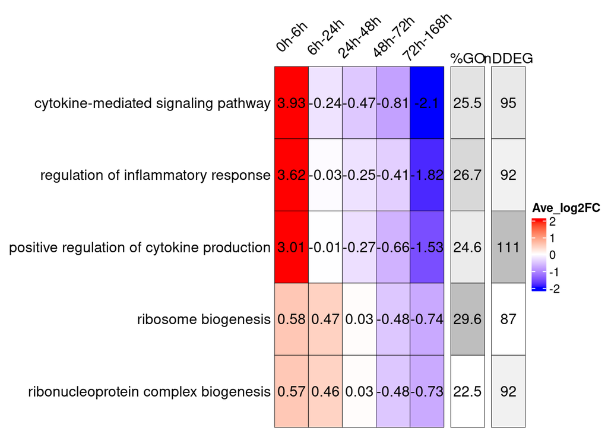

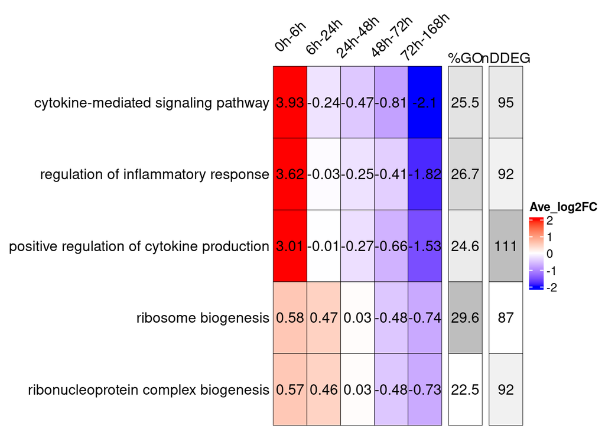

```r
go.terms<-unique(time_heatmap$GO.df$Description)[1:5]
time_heatmap_selGO<-draw_TimeHeatmap_selGO(time_heatmap = time_heatmap, sel.go = go.terms, master.list = master.list, GO.perc.thres = 0, nDDEG.thres = 0)
```

#### 5. Look at Genes candidates from picked enriched GO terms.

To look at which genes are involved within the TimeHeatmap above. We can call draw_GOHeatmap function. This function is useful when one is comparing multiple projects.

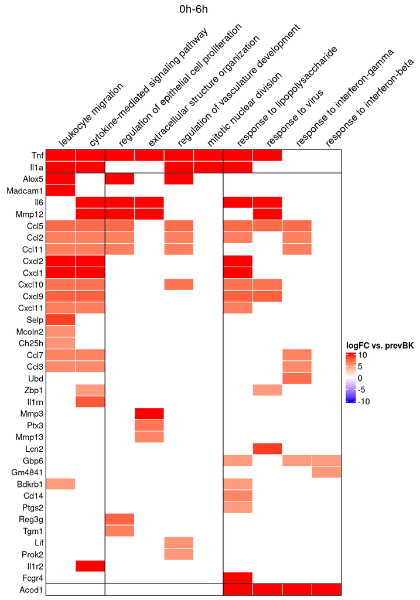

```r
go.terms<-c("response to lipopolysaccharide",
            "response to interferon-beta",
            "cytokine-mediated signaling pathway",
            "response to interferon-gamma",
            "response to virus",
            "leukocyte migration",
            "mitotic nuclear division",
            "regulation of vasculature development",
            "extracellular structure organization",
            "regulation of epithelial cell proliferation")
gene.GO.df<-draw_GOHeatmap(master.list = master.list, time.window = "0h-6h",
                           go.terms = go.terms,  merge.df = time_heatmap$merge.df,
                           logFC.thres = 5)
```

The data.frame gene.GO.df contains all the genes we found through TrendCatcher without logFC threshold.

```r
head(gene.GO.df)
```

```
##         type                         Description  gene logFC.prev.bk prev.bk.t
## 1 Activation cytokine-mediated signaling pathway  Ccl3      5.951150         0
## 2 Activation cytokine-mediated signaling pathway Ccl11      6.495073         0
## 3 Activation cytokine-mediated signaling pathway   Tnf     32.479065         0
## 4 Activation cytokine-mediated signaling pathway   Il6     10.157610         0
## 5 Activation cytokine-mediated signaling pathway Il1r2     32.384983         0
## 6 Activation cytokine-mediated signaling pathway Il1rn      8.137336         0
##   Symbol
## 1   Ccl3
## 2  Ccl11
## 3    Tnf
## 4    Il6
## 5  Il1r2
## 6  Il1rn
```